# DSC 478 Syed Noor Razi Ali- 2070326

# ASSIGNMENT 1

[5 pts] Download the data set adult-modified.csv and load it into an appropriate data structure such as a Pandas dataframe. Explore the general characteristics of the data as a whole: examine the means, standard deviations, and other statistics associated with the numeric attributes and frequencies associated with categorical attributes

```python
import numpy as np
import pandas as pd
import matplotlib.pyplot as plt
```

```python
#reading the csv file
data = pd.read_csv("adult-modified.csv")
```

```python
#fetching the first few details of the data
data.head()
```

|  | age | workclass | education | marital-status | race | sex | hours-per-week | income |
| --- | --- | --- | --- | --- | --- | --- | --- | --- |
| 0 | 39 | Public | 13 | Single | White | Male | 40 | <=50K |
| 1 | 50 | Self-emp | 13 | Married | White | Male | 13 | <=50K |
| 2 | 38 | Private | 9 | Single | White | Male | 40 | <=50K |
| 3 | 53 | Private | 7 | Married | Black | Male | 40 | <=50K |
| 4 | 28 | Private | 13 | Married | Black | Female | 40 | <=50K |

```python
#getting the number of rows and columns
data.shape
```

```
(9412, 8)
```

```python
#checking the datatypes of the data
data.dtypes
```

```
age                int64
workclass         object
education          int64
marital-status    object
race              object
sex               object
hours-per-week     int64
income            object
dtype: object
```

```python
# checking the summary statistics of the Numerical data
data.describe()
```

|  | age | education | hours-per-week |
| --- | --- | --- | --- |
| count | 9412.000000 | 9412.000000 | 9412.000000 |
| mean | 38.357310 | 10.125266 | 41.080217 |
| std | 12.962135 | 2.542118 | 11.884590 |
| min | 17.000000 | 1.000000 | 1.000000 |
| 25% | 28.000000 | 9.000000 | 40.000000 |
| 50% | 37.000000 | 10.000000 | 40.000000 |
| 75% | 47.000000 | 13.000000 | 45.000000 |
| max | 90.000000 | 16.000000 | 99.000000 |

```python
#checking for any missing values in the data
data.isnull().sum()
```

```
age               0
workclass         0
education         0
marital-status    0
race              0
sex               0
hours-per-week    0
income            0
dtype: int64
```

Checking the value counts of the categorical attributes

```python
data['workclass'].value_counts()
```

```
Private     6947
Public      1317
Self-emp    1148
Name: workclass, dtype: int64
```

```python
data['marital-status'].value_counts()
```

```
Married    4737
Single     4675
Name: marital-status, dtype: int64
```

```python
data['race'].value_counts()
```

```
White          8062
Black           892
Asian           291
Amer-Indian      92
Hispanic         75
Name: race, dtype: int64
```

```python
data['sex'].value_counts()
```

```
Male      6383
Female    3029
Name: sex, dtype: int64
```

```python
data['income'].value_counts()
```

```
<=50K    7093
>50K     2319
Name: income, dtype: int64
```

2.

[5 pts] For the three numeric attributes (age, hours-per-week, education), display box plots that show the overall dispersion and skew in these variables. Next, create histograms for these three variables showing the overall data distribution in each. Finally, display a scatter plot of age (x-axis) vs. hours-per-week (y-axis).

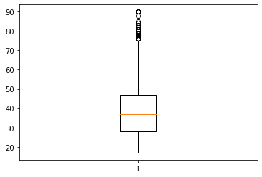

```python
#creating boxplots of age showing the outliers and dispersion
plt.boxplot(data['age'])
plt.show()
```

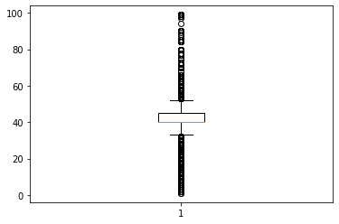

```python
##creating boxplots of hours per week showing the outliers
plt.boxplot(data['hours-per-week'])
plt.show()
```

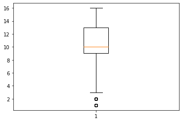

```python
#creating boxplots of education showing the outliers
plt.boxplot(data['education'])
plt.show()
```

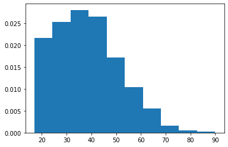

```python
# Histograms
plt.hist(data['age'],density = True,
         histtype ='bar')
```

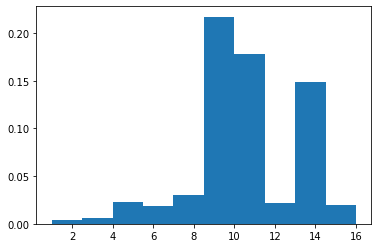

```python
# Histograms
plt.hist(data['education'],density = True,
         histtype ='bar')
```

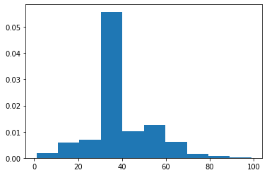

```python
# Histograms
plt.hist(data['hours-per-week'],density = True,
         histtype ='bar')
```

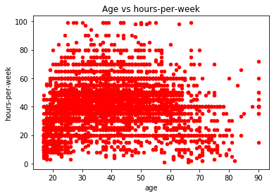

```python
# Scatterplot of age vs hours-per-week
data.plot.scatter(x='age',y='hours-per-week',title='Age vs hours-per-week',c='red')
plt.show()
```

3.

[5 pts] For the remaining categorical attributes create bar charts that show the distribution of category frequencies (e.g., married vs. single; private vs. public vs. self-emp; etc). Ideally, you should use bar charts in a single figure similar to this figure

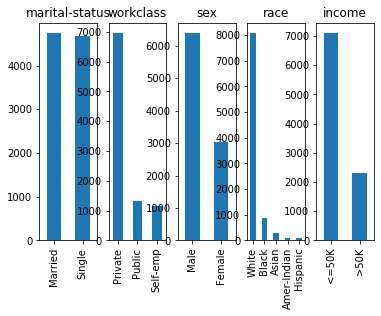

```python
categorical_features = ["marital-status","workclass","sex","race","income"]
pl, ax = plt.subplots(1, len(categorical_features))
for i, categorical_feature in enumerate(data[categorical_features]):
    data[categorical_feature].value_counts().plot("bar", ax=ax[i]).set_title(categorical_feature)

plt.show()
```

4.

[5 pts] Perform a cross-tabulations of each of the workclass and race attributes with the income attribute. Show the resulting cross-tab tables as well as bar charts to visualize the relationships between these pairs of attributes. [Hint: you can use aggregation functions in Pandas such as groupby() and cross-tab(), then either using Matplotlib directly or the plot() function in Pandas create the bar charts]. As an illustration, consider this graph depicting the cross-tabulation of sex with income. In the case of race vs. income cross-tab, create another chart comparing the percentages of each race category that fall in the low-income group

```
income     <=50K  >50K
workclass
Private     5443  1504
Public       925   392
Self-emp     725   423
```

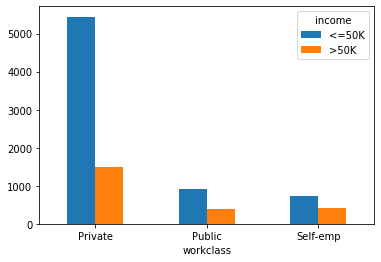

```python
#
crosstb = pd.crosstab(data['workclass'], data['income'])
print(crosstb)
barplot = crosstb.plot.bar(rot=0)
barplot
```

```
income       <=50K  >50K
race
Amer-Indian     83     9
Asian          224    67
Black          773   119
Hispanic        69     6
White         5944  2118
```

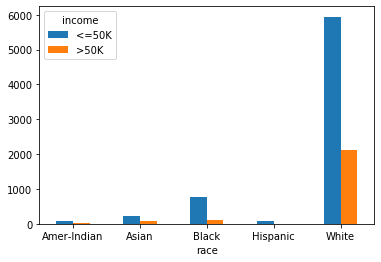

```python
crosstb1 = pd.crosstab(data['race'], data['income'])
print(crosstb1)
barplot1 = crosstb1.plot.bar(rot=0)
barplot1
```

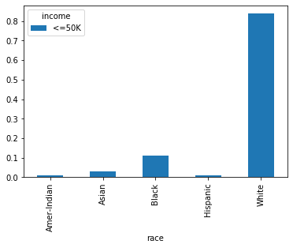

```python
perc = lambda x: x/x.sum()
crosstb1 = crosstb1.apply(perc)
crosstb1
low_inc = crosstb1[["<=50K"]]
plt.show(low_inc.plot(kind = 'bar'))
```

5.

[10 pts] Compare and contrast the characteristics of the low-income and high-income categories across the different attributes. You may consider first creating separate subsets of the data based on the income categories and then characterizing each subset by observing summary statistics for each group across different variables. Discuss your observations focusing specifically on unique characteristics that seem to distinguish among the two groups. You may (though you are not required to) use charts or plots for visualizing the differences in your analysis.

```python
# subset of low income
low_income = data[data.income== '<=50K']
low_income
```

|  | age | workclass | education | marital-status | race | sex | hours-per-week | income |
| --- | --- | --- | --- | --- | --- | --- | --- | --- |
| 0 | 39 | Public | 13 | Single | White | Male | 40 | <=50K |
| 1 | 50 | Self-emp | 13 | Married | White | Male | 13 | <=50K |
| 2 | 38 | Private | 9 | Single | White | Male | 40 | <=50K |
| 3 | 53 | Private | 7 | Married | Black | Male | 40 | <=50K |
| 4 | 28 | Private | 13 | Married | Black | Female | 40 | <=50K |
| ... | ... | ... | ... | ... | ... | ... | ... | ... |
| 9406 | 34 | Self-emp | 11 | Married | White | Male | 75 | <=50K |
| 9408 | 25 | Private | 9 | Single | White | Female | 8 | <=50K |
| 9409 | 21 | Private | 10 | Single | Black | Male | 40 | <=50K |
| 9410 | 38 | Private | 2 | Married | White | Male | 53 | <=50K |
| 9411 | 39 | Private | 10 | Single | White | Female | 40 | <=50K |

7093 rows × 8 columns

```python
low_income.describe()
```

|  | age | education | hours-per-week |
| --- | --- | --- | --- |
| count | 7093.000000 | 7093.000000 | 7093.000000 |
| mean | 36.635979 | 9.646976 | 39.567038 |
| std | 13.339117 | 2.397358 | 11.868506 |
| min | 17.000000 | 1.000000 | 1.000000 |
| 25% | 26.000000 | 9.000000 | 38.000000 |
| 50% | 35.000000 | 9.000000 | 40.000000 |
| 75% | 45.000000 | 10.000000 | 40.000000 |
| max | 90.000000 | 16.000000 | 99.000000 |

```python
# subset of high income
high_income = data[data.income== '>50K']
high_income
```

|  | age | workclass | education | marital-status | race | sex | hours-per-week | income |
| --- | --- | --- | --- | --- | --- | --- | --- | --- |
| 7 | 52 | Self-emp | 9 | Married | White | Male | 45 | >50K |
| 8 | 31 | Private | 14 | Single | White | Female | 50 | >50K |
| 9 | 42 | Private | 13 | Married | White | Male | 40 | >50K |
| 10 | 37 | Private | 10 | Married | Black | Male | 80 | >50K |
| 11 | 30 | Public | 13 | Married | Asian | Male | 40 | >50K |
| ... | ... | ... | ... | ... | ... | ... | ... | ... |
| 9372 | 40 | Private | 9 | Married | Black | Male | 40 | >50K |
| 9375 | 47 | Private | 13 | Married | White | Male | 60 | >50K |
| 9379 | 38 | Private | 13 | Married | White | Male | 50 | >50K |
| 9385 | 43 | Public | 14 | Single | Black | Female | 40 | >50K |
| 9407 | 38 | Private | 10 | Married | White | Male | 60 | >50K |

2319 rows × 8 columns

```python
high_income.describe()
```

|  | age | education | hours-per-week |
| --- | --- | --- | --- |
| count | 2319.000000 | 2319.000000 | 2319.000000 |
| mean | 43.622251 | 11.588185 | 45.708495 |
| std | 10.047667 | 2.410764 | 10.678794 |
| min | 19.000000 | 2.000000 | 1.000000 |
| 25% | 36.000000 | 9.000000 | 40.000000 |
| 50% | 43.000000 | 12.000000 | 40.000000 |
| 75% | 50.000000 | 13.000000 | 50.000000 |
| max | 90.000000 | 16.000000 | 99.000000 |

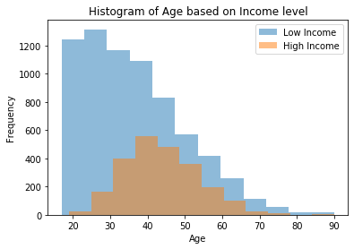

```python
plt.hist(low_income["age"], bins=12, alpha=0.5, label ="Low")
plt.hist(high_income["age"], bins=12, alpha=0.5, label = "high")
plt.xlabel('Age')
plt.ylabel('Frequency')
plt.title('Histogram of Age based on Income level')
plt.legend(["Low Income", "High Income"])
```

6.

[5 pts] Convert the data into the standard spreadsheet format. Note that this requires converting each categorical attribute into multiple binary ("dummy") attributes (one for each values of the categorical attribute) and assigning binary values corresponding to the presence or not presence of the attribute value in the original record). The numeric attributes should remain unchanged. Save this data in a new dataframe and show the top 10 rows in the new dataframe. Also save this new table into a local file called adult_numeric.csv

```python
adult_numeric= pd.get_dummies(data)
adult_numeric.head(10)
```

|  | age | education | hours-per-week | workclass_Private | workclass_Public | workclass_Self-emp | marital-status_Married | marital-status_Single | race_Amer-Indian | race_Asian | race_Black | race_Hispanic | race_White | sex_Female | sex_Male | income_<=50K | income_>50K |
| --- | --- | --- | --- | --- | --- | --- | --- | --- | --- | --- | --- | --- | --- | --- | --- | --- | --- |
| 0 | 39 | 13 | 40 | 0 | 1 | 0 | 0 | 1 | 0 | 0 | 0 | 0 | 1 | 0 | 1 | 1 | 0 |
| 1 | 50 | 13 | 13 | 0 | 0 | 1 | 1 | 0 | 0 | 0 | 0 | 0 | 1 | 0 | 1 | 1 | 0 |
| 2 | 38 | 9 | 40 | 1 | 0 | 0 | 0 | 1 | 0 | 0 | 0 | 0 | 1 | 0 | 1 | 1 | 0 |
| 3 | 53 | 7 | 40 | 1 | 0 | 0 | 1 | 0 | 0 | 0 | 1 | 0 | 0 | 0 | 1 | 1 | 0 |
| 4 | 28 | 13 | 40 | 1 | 0 | 0 | 1 | 0 | 0 | 0 | 1 | 0 | 0 | 1 | 0 | 1 | 0 |
| 5 | 37 | 14 | 40 | 1 | 0 | 0 | 1 | 0 | 0 | 0 | 0 | 0 | 1 | 1 | 0 | 1 | 0 |
| 6 | 49 | 5 | 16 | 1 | 0 | 0 | 1 | 0 | 0 | 0 | 1 | 0 | 0 | 1 | 0 | 1 | 0 |
| 7 | 52 | 9 | 45 | 0 | 0 | 1 | 1 | 0 | 0 | 0 | 0 | 0 | 1 | 0 | 1 | 0 | 1 |
| 8 | 31 | 14 | 50 | 1 | 0 | 0 | 0 | 1 | 0 | 0 | 0 | 0 | 1 | 1 | 0 | 0 | 1 |
| 9 | 42 | 13 | 40 | 1 | 0 | 0 | 1 | 0 | 0 | 0 | 0 | 0 | 1 | 0 | 1 | 0 | 1 |

```python
adult_numeric.describe()
```

|  | age | education | hours-per-week | workclass_Private | workclass_Public | workclass_Self-emp | marital-status_Married | marital-status_Single | race_Amer-Indian | race_Asian | race_Black | race_Hispanic | race_White | sex_Female | sex_Male | income_<=50K | income_>50K |
| --- | --- | --- | --- | --- | --- | --- | --- | --- | --- | --- | --- | --- | --- | --- | --- | --- | --- |
| count | 9412.000000 | 9412.000000 | 9412.000000 | 9412.000000 | 9412.000000 | 9412.000000 | 9412.000000 | 9412.000000 | 9412.000000 | 9412.000000 | 9412.000000 | 9412.000000 | 9412.000000 | 9412.000000 | 9412.000000 | 9412.000000 | 9412.000000 |
| mean | 38.357310 | 10.125266 | 41.080217 | 0.738100 | 0.139928 | 0.121972 | 0.503294 | 0.496706 | 0.009775 | 0.030918 | 0.094773 | 0.007969 | 0.856566 | 0.321823 | 0.678177 | 0.753612 | 0.246388 |
| std | 12.962135 | 2.542118 | 11.884590 | 0.439692 | 0.346930 | 0.327271 | 0.500016 | 0.500016 | 0.098388 | 0.173105 | 0.292916 | 0.088915 | 0.350533 | 0.467200 | 0.467200 | 0.430930 | 0.430930 |
| min | 17.000000 | 1.000000 | 1.000000 | 0.000000 | 0.000000 | 0.000000 | 0.000000 | 0.000000 | 0.000000 | 0.000000 | 0.000000 | 0.000000 | 0.000000 | 0.000000 | 0.000000 | 0.000000 | 0.000000 |
| 25% | 28.000000 | 9.000000 | 40.000000 | 0.000000 | 0.000000 | 0.000000 | 0.000000 | 0.000000 | 0.000000 | 0.000000 | 0.000000 | 0.000000 | 1.000000 | 0.000000 | 0.000000 | 1.000000 | 0.000000 |
| 50% | 37.000000 | 10.000000 | 40.000000 | 1.000000 | 0.000000 | 0.000000 | 1.000000 | 0.000000 | 0.000000 | 0.000000 | 0.000000 | 0.000000 | 1.000000 | 0.000000 | 1.000000 | 1.000000 | 0.000000 |
| 75% | 47.000000 | 13.000000 | 45.000000 | 1.000000 | 0.000000 | 0.000000 | 1.000000 | 1.000000 | 0.000000 | 0.000000 | 0.000000 | 0.000000 | 1.000000 | 1.000000 | 1.000000 | 1.000000 | 0.000000 |
| max | 90.000000 | 16.000000 | 99.000000 | 1.000000 | 1.000000 | 1.000000 | 1.000000 | 1.000000 | 1.000000 | 1.000000 | 1.000000 | 1.000000 | 1.000000 | 1.000000 | 1.000000 | 1.000000 | 1.000000 |

```python
adult_numeric.shape
```

```
(9412, 17)
```

```python
adult_numeric.to_csv("adult_numeric.csv")
```

7.

[10 pts] Using the numeric data set with the dummy variables (of the previous part), perform basic correlation analysis among the attributes. You need to construct a complete Correlation Matrix (with rows and columns corresponding to each variable). [Hint: you can create the correlation matrix by using the corr() function in Pandas or corrcoef function in NumPy]. Next, using your correlation matrix, display in decreasing order of correlations, all attributes and their correlations to education. Repeat this step to display correlations with the attribute income_<=50K. Briefly discuss your general observations about this sample of adult population based on this correlation analysis.

```python
cor_matrix = adult_numeric.corr()
cor_matrix
```

|  | age | education | hours-per-week | workclass_Private | workclass_Public | workclass_Self-emp | marital-status_Married | marital-status_Single | race_Amer-Indian | race_Asian | race_Black | race_Hispanic | race_White | sex_Female | sex_Male | income_<=50K | income_>50K |
| --- | --- | --- | --- | --- | --- | --- | --- | --- | --- | --- | --- | --- | --- | --- | --- | --- | --- |
| age | 1.000000 | 0.034733 | 0.103170 | -0.202982 | 0.080254 | 0.187633 | 0.381168 | -0.381168 | -0.010904 | -0.008097 | -0.008668 | -0.031973 | 0.022413 | -0.071804 | 0.071804 | -0.232261 | 0.232261 |
| education | 0.034733 | 1.000000 | 0.141730 | -0.154977 | 0.154462 | 0.044472 | 0.050627 | -0.050627 | -0.039308 | 0.057360 | -0.069029 | -0.044845 | 0.051765 | -0.008180 | 0.008180 | -0.329066 | 0.329066 |
| hours-per-week | 0.103170 | 0.141730 | 1.000000 | -0.097753 | -0.021407 | 0.154025 | 0.183944 | -0.183944 | 0.002964 | 0.000550 | -0.071442 | 0.011964 | 0.055561 | -0.221588 | 0.221588 | -0.222686 | 0.222686 |
| workclass_Private | -0.202982 | -0.154977 | -0.097753 | 1.000000 | -0.677134 | -0.625700 | -0.121014 | 0.121014 | -0.007136 | -0.015060 | 0.004632 | 0.023490 | -0.000389 | 0.072569 | -0.072569 | 0.116453 | -0.116453 |
| workclass_Public | 0.080254 | 0.154462 | -0.021407 | -0.677134 | 1.000000 | -0.150335 | -0.002351 | 0.002351 | 0.022185 | 0.012883 | 0.070250 | -0.018927 | -0.066491 | 0.045338 | -0.045338 | -0.047981 | 0.047981 |
| workclass_Self-emp | 0.187633 | 0.044472 | 0.154025 | -0.625700 | -0.150335 | 1.000000 | 0.165075 | -0.165075 | -0.013931 | 0.006576 | -0.080694 | -0.011495 | 0.071008 | -0.145559 | 0.145559 | -0.105593 | 0.105593 |
| marital-status_Married | 0.381168 | 0.050627 | 0.183944 | -0.121014 | -0.002351 | 0.165075 | 1.000000 | -1.000000 | -0.013614 | 0.017852 | -0.104427 | 0.000605 | 0.082114 | -0.357736 | 0.357736 | -0.414173 | 0.414173 |
| marital-status_Single | -0.381168 | -0.050627 | -0.183944 | 0.121014 | 0.002351 | -0.165075 | -1.000000 | 1.000000 | 0.013614 | -0.017852 | 0.104427 | -0.000605 | -0.082114 | 0.357736 | -0.357736 | 0.414173 | -0.414173 |
| race_Amer-Indian | -0.010904 | -0.039308 | 0.002964 | -0.007136 | 0.022185 | -0.013931 | -0.013614 | 0.013614 | 1.000000 | -0.017746 | -0.032148 | -0.008905 | -0.242795 | 0.021711 | -0.021711 | 0.034254 | -0.034254 |
| race_Asian | -0.008097 | 0.057360 | 0.000550 | -0.015060 | 0.012883 | 0.006576 | 0.017852 | -0.017852 | -0.017746 | 1.000000 | -0.057795 | -0.016009 | -0.436496 | 0.001773 | -0.001773 | 0.006693 | -0.006693 |
| race_Black | -0.008668 | -0.069029 | -0.071442 | 0.004632 | 0.070250 | -0.080694 | -0.104427 | 0.104427 | -0.032148 | -0.057795 | 1.000000 | -0.028999 | -0.790710 | 0.106323 | -0.106323 | 0.084836 | -0.084836 |
| race_Hispanic | -0.031973 | -0.044845 | 0.011964 | 0.023490 | -0.018927 | -0.011495 | 0.000605 | -0.000605 | -0.008905 | -0.016009 | -0.028999 | 1.000000 | -0.219019 | 0.004766 | -0.004766 | 0.034607 | -0.034607 |
| race_White | 0.022413 | 0.051765 | 0.055561 | -0.000389 | -0.066491 | 0.071008 | 0.082114 | -0.082114 | -0.242795 | -0.436496 | -0.790710 | -0.219019 | 1.000000 | -0.097025 | 0.097025 | -0.092589 | 0.092589 |
| sex_Female | -0.071804 | -0.008180 | -0.221588 | 0.072569 | 0.045338 | -0.145559 | -0.357736 | 0.357736 | 0.021711 | 0.001773 | 0.106323 | 0.004766 | -0.097025 | 1.000000 | -1.000000 | 0.203886 | -0.203886 |
| sex_Male | 0.071804 | 0.008180 | 0.221588 | -0.072569 | -0.045338 | 0.145559 | 0.357736 | -0.357736 | -0.021711 | -0.001773 | -0.106323 | -0.004766 | 0.097025 | -1.000000 | 1.000000 | -0.203886 | 0.203886 |
| income_<=50K | -0.232261 | -0.329066 | -0.222686 | 0.116453 | -0.047981 | -0.105593 | -0.414173 | 0.414173 | 0.034254 | 0.006693 | 0.084836 | 0.034607 | -0.092589 | 0.203886 | -0.203886 | 1.000000 | -1.000000 |
| income_>50K | 0.232261 | 0.329066 | 0.222686 | -0.116453 | 0.047981 | 0.105593 | 0.414173 | -0.414173 | -0.034254 | -0.006693 | -0.084836 | -0.034607 | 0.092589 | -0.203886 | 0.203886 | -1.000000 | 1.000000 |

```python
#Correlation of all the attributes with respect to education <=50K in desscending order
cor_matrix["education"].sort_values(ascending=False)
```

```
education                 1.000000
income_>50K               0.329066
workclass_Public          0.154462
hours-per-week            0.141730
race_Asian                0.057360
race_White                0.051765
marital-status_Married    0.050627
workclass_Self-emp        0.044472
age                       0.034733
sex_Male                  0.008180
sex_Female               -0.008180
race_Amer-Indian         -0.039308
race_Hispanic            -0.044845
marital-status_Single    -0.050627
race_Black               -0.069029
workclass_Private        -0.154977
income_<=50K             -0.329066
Name: education, dtype: float64
```

```python
#Correlation of all the attributes with respect to income <=50K in desscending order
cor_matrix["income_<=50K"].sort_values(ascending=False)
```

```
income_<=50K              1.000000
marital-status_Single     0.414173
sex_Female                0.203886
workclass_Private         0.116453
race_Black                0.084836
race_Hispanic             0.034607
race_Amer-Indian          0.034254
race_Asian                0.006693
workclass_Public         -0.047981
race_White               -0.092589
workclass_Self-emp       -0.105593
sex_Male                 -0.203886
hours-per-week           -0.222686
age                      -0.232261
education                -0.329066
marital-status_Married   -0.414173
income_>50K              -1.000000
Name: income_<=50K, dtype: float64
```

8.

Discretize the age attribute into 3 categories (corresponding to "young", "mid-age", and "old"). Do not change the original age attribute or add the discretized age to the table. Create a new dataframe with the numeric and the discretized age attributes as two columns and display the top 10 rows of the new dataframe

```python
#discretising age variable into 'young', 'mid-age', 'old'
age_bins = pd.qcut(adult_numeric.age, 3)
age_bins = pd.qcut(adult_numeric.age, [0, .33, .66, 1], labels=["young", "mid-age", "old"])
age_bins.head(10)
```

```
0    mid-age
1        old
2    mid-age
3        old
4      young
5    mid-age
6        old
7        old
8      young
9    mid-age
Name: age, dtype: category
Categories (3, object): [young < mid-age < old]
```

```python
new_data = adult_numeric.copy()
new_data.head()
```

|  | age | education | hours-per-week | workclass_Private | workclass_Public | workclass_Self-emp | marital-status_Married | marital-status_Single | race_Amer-Indian | race_Asian | race_Black | race_Hispanic | race_White | sex_Female | sex_Male | income_<=50K | income_>50K |
| --- | --- | --- | --- | --- | --- | --- | --- | --- | --- | --- | --- | --- | --- | --- | --- | --- | --- |
| 0 | 39 | 13 | 40 | 0 | 1 | 0 | 0 | 1 | 0 | 0 | 0 | 0 | 1 | 0 | 1 | 1 | 0 |
| 1 | 50 | 13 | 13 | 0 | 0 | 1 | 1 | 0 | 0 | 0 | 0 | 0 | 1 | 0 | 1 | 1 | 0 |
| 2 | 38 | 9 | 40 | 1 | 0 | 0 | 0 | 1 | 0 | 0 | 0 | 0 | 1 | 0 | 1 | 1 | 0 |
| 3 | 53 | 7 | 40 | 1 | 0 | 0 | 1 | 0 | 0 | 0 | 1 | 0 | 0 | 0 | 1 | 1 | 0 |
| 4 | 28 | 13 | 40 | 1 | 0 | 0 | 1 | 0 | 0 | 0 | 1 | 0 | 0 | 1 | 0 | 1 | 0 |

```python
new_data["age_bins"] = age_bins
new_data.head()
```

|  | age | education | hours-per-week | workclass_Private | workclass_Public | workclass_Self-emp | marital-status_Married | marital-status_Single | race_Amer-Indian | race_Asian | race_Black | race_Hispanic | race_White | sex_Female | sex_Male | income_<=50K | income_>50K | age_bins |
| --- | --- | --- | --- | --- | --- | --- | --- | --- | --- | --- | --- | --- | --- | --- | --- | --- | --- | --- |
| 0 | 39 | 13 | 40 | 0 | 1 | 0 | 0 | 1 | 0 | 0 | 0 | 0 | 1 | 0 | 1 | 1 | 0 | mid-age |
| 1 | 50 | 13 | 13 | 0 | 0 | 1 | 1 | 0 | 0 | 0 | 0 | 0 | 1 | 0 | 1 | 1 | 0 | old |
| 2 | 38 | 9 | 40 | 1 | 0 | 0 | 0 | 1 | 0 | 0 | 0 | 0 | 1 | 0 | 1 | 1 | 0 | mid-age |
| 3 | 53 | 7 | 40 | 1 | 0 | 0 | 1 | 0 | 0 | 0 | 1 | 0 | 0 | 0 | 1 | 1 | 0 | old |
| 4 | 28 | 13 | 40 | 1 | 0 | 0 | 1 | 0 | 0 | 0 | 1 | 0 | 0 | 1 | 0 | 1 | 0 | young |

9.

[10 pts] Use Min-Max Normalization to transform the values of the attribute hours-per-week the range 0.0-1.0 (without changing the original data). Next, perform zscore normalization to standardize the values of all numeric attributes (age, hours-per-week, education). The latter step should be performed on all three attributes at the same time instead of one-by-one (you may wish to first create a separate dataframe with only these attributes and perform the operation on the whole dataframe. Note: for this problem, you should write your own code to perform the normalization; do not use pre-existing functions such as scikit-learn's MinMaxScaler(). Finally, show the top 10 rows of the three versions of the hours-per-week attribute (original, normalized, and standardized) side-by-side in a new dataframe

```python
# Original data
data.head()
```

|  | age | workclass | education | marital-status | race | sex | hours-per-week | income |
| --- | --- | --- | --- | --- | --- | --- | --- | --- |
| 0 | 39 | Public | 13 | Single | White | Male | 40 | <=50K |
| 1 | 50 | Self-emp | 13 | Married | White | Male | 13 | <=50K |
| 2 | 38 | Private | 9 | Single | White | Male | 40 | <=50K |
| 3 | 53 | Private | 7 | Married | Black | Male | 40 | <=50K |
| 4 | 28 | Private | 13 | Married | Black | Female | 40 | <=50K |

```python
data.shape
```

```
(9412, 8)
```

```python
#Min max normalization of hours-per-week
min_hours = data["hours-per-week"].min()
max_hours = data["hours-per-week"].max()
normalised_data = (data["hours-per-week"]- min_hours)/(max_hours-min_hours)
normalised_data.head()
```

```
0    0.397959
1    0.122449
2    0.397959
3    0.397959
4    0.397959
Name: hours-per-week, dtype: float64
```

```python
#zscore normalization of age, education and hours-per-week
data_num = data[["age", "hours-per-week", "education"]]
zscore = lambda x: (x - x.mean()) / x.std()
data_std = data_num.apply(zscore)
data_std.head()
```

|  | age | hours-per-week | education |
| --- | --- | --- | --- |
| 0 | 0.049582 | -0.090892 | 1.130842 |
| 1 | 0.898208 | -2.362742 | 1.130842 |
| 2 | -0.027566 | -0.090892 | -0.442649 |
| 3 | 1.129651 | -0.090892 | -1.229394 |
| 4 | -0.799044 | -0.090892 | 1.130842 |

```python
#All three versions of Hours-per-week
norm= pd.DataFrame(data[["hours-per-week"]])
norm["Min-Max"] = normalised_data
norm["z-score"] = data_std[["hours-per-week"]]
norm.head(10)
```

|  | hours-per-week | Min-Max | z-score |
| --- | --- | --- | --- |
| 0 | 40 | 0.397959 | -0.090892 |
| 1 | 13 | 0.122449 | -2.362742 |
| 2 | 40 | 0.397959 | -0.090892 |
| 3 | 40 | 0.397959 | -0.090892 |
| 4 | 40 | 0.397959 | -0.090892 |
| 5 | 40 | 0.397959 | -0.090892 |
| 6 | 16 | 0.153061 | -2.110314 |
| 7 | 45 | 0.448980 | 0.329821 |
| 8 | 50 | 0.500000 | 0.750534 |
| 9 | 40 | 0.397959 | -0.090892 |

10

Now download a modified version of the data (adult-modified-missing-vals.csv) that contains missing values. (a) Using Pandas determine all the attributes with missing values and the number of missing values for each such attribute. (b) Show all the instances in the data that contain a missing value. (c) Fill the missing values for all numeric attributes using the mean value for the attribute. (d) After filling in the missing numeric values, drop all rows where a categorical attribute contains a missing value. (e) Show that the final resulting table does not contain missing values

```python
modified_data = pd.read_csv("adult-modified-missing-vals.csv", na_values =["?"])
modified_data.head()
```

|  | age | workclass | education | marital-status | race | sex | hours-per-week | income |
| --- | --- | --- | --- | --- | --- | --- | --- | --- |
| 0 | 39.0 | Public | 13 | Single | White | Male | 40 | <=50K |
| 1 | 50.0 | Self-emp | 13 | Married | White | Male | 13 | <=50K |
| 2 | 38.0 | Private | 9 | Single | White | Male | 40 | <=50K |
| 3 | 53.0 | Private | 7 | Married | Black | Male | 40 | <=50K |
| 4 | 28.0 | Private | 13 | Married | Black | Female | 40 | <=50K |

```python
#a
modified_data.isnull()
```

|  | age | workclass | education | marital-status | race | sex | hours-per-week | income |
| --- | --- | --- | --- | --- | --- | --- | --- | --- |
| 0 | False | False | False | False | False | False | False | False |
| 1 | False | False | False | False | False | False | False | False |
| 2 | False | False | False | False | False | False | False | False |
| 3 | False | False | False | False | False | False | False | False |
| 4 | False | False | False | False | False | False | False | False |
| ... | ... | ... | ... | ... | ... | ... | ... | ... |
| 9995 | False | False | False | False | False | False | False | False |
| 9996 | False | False | False | False | False | False | False | False |
| 9997 | False | False | False | False | False | False | False | False |
| 9998 | True | False | False | False | False | False | False | False |
| 9999 | False | False | False | False | False | False | False | False |

10000 rows × 8 columns

```python
#a
modified_data.isnull().sum()
```

```
age               198
workclass         588
education           0
marital-status      0
race                0
sex                 0
hours-per-week      0
income              0
dtype: int64
```

```python
#b
#B-Shows which rows have missing age
modified_data[modified_data.age.isnull()]
```

|  | age | workclass | education | marital-status | race | sex | hours-per-week | income |
| --- | --- | --- | --- | --- | --- | --- | --- | --- |
| 19 | NaN | Self-emp | 14 | Single | White | Female | 45 | >50K |
| 27 | NaN | NaN | 10 | Married | Asian | Male | 60 | >50K |
| 40 | NaN | Private | 5 | Married | White | Male | 43 | <=50K |
| 65 | NaN | Private | 9 | Married | White | Male | 40 | <=50K |
| 80 | NaN | Private | 9 | Single | White | Male | 30 | <=50K |
| ... | ... | ... | ... | ... | ... | ... | ... | ... |
| 9944 | NaN | Private | 12 | Single | White | Female | 45 | <=50K |
| 9965 | NaN | Private | 10 | Married | Amer-Indian | Female | 40 | <=50K |
| 9966 | NaN | Private | 13 | Married | White | Male | 50 | >50K |
| 9993 | NaN | Private | 9 | Married | White | Female | 15 | <=50K |
| 9998 | NaN | Private | 2 | Married | White | Male | 53 | <=50K |

198 rows × 8 columns

```python
#B-Shows which rows have missing workclass
modified_data[modified_data.workclass.isnull()]
```

|  | age | workclass | education | marital-status | race | sex | hours-per-week | income |
| --- | --- | --- | --- | --- | --- | --- | --- | --- |
| 27 | NaN | NaN | 10 | Married | Asian | Male | 60 | >50K |
| 61 | 32.0 | NaN | 4 | Married | White | Male | 40 | <=50K |
| 69 | 25.0 | NaN | 10 | Single | White | Male | 40 | <=50K |
| 77 | 67.0 | NaN | 6 | Married | White | Male | 2 | <=50K |
| 106 | 17.0 | NaN | 6 | Single | White | Female | 32 | <=50K |
| ... | ... | ... | ... | ... | ... | ... | ... | ... |
| 9907 | 68.0 | NaN | 9 | Married | White | Male | 15 | <=50K |
| 9926 | 73.0 | NaN | 7 | Married | White | Male | 8 | <=50K |
| 9927 | 18.0 | NaN | 7 | Single | White | Female | 20 | <=50K |
| 9938 | 36.0 | NaN | 10 | Single | White | Female | 25 | <=50K |
| 9987 | 67.0 | NaN | 4 | Married | White | Male | 40 | <=50K |

588 rows × 8 columns

```python
#C- replacing the Nan with the mean of the age variable
age_mean = modified_data.age.mean()
modified_data.age.fillna(age_mean, axis=0, inplace=True)
modified_data[modified_data.age.isnull()]
```

|  | age | workclass | education | marital-status | race | sex | hours-per-week | income |
| --- | --- | --- | --- | --- | --- | --- | --- | --- |

```python
#D - Dropping all rows that has missing workclass
modified_data = modified_data.drop(modified_data[modified_data.workclass.isnull()].index, axis=0)
```

```python
#E
modified_data.isnull().sum()
```

```
age               0
workclass         0
education         0
marital-status    0
race              0
sex               0
hours-per-week    0
income            0
dtype: int64
```